# Computer lab 4: Solutions

Richard Wilkinson

## Computational exercises from notes

Let’s look at the example
$$\begin{align*}
\min x_1^{2}+2 x_2^{2}
\end{align*}$$

Start by implementing a function to compute f and its gradient, and check this calculation numerically. I have written a collection of functions implementing the methods in this chapter and put them on Moodle. If you download this file and put it in your working directory, you can then load the functions as follows:

```r
source('GradientDescentFunctions.R')
```

I’ll print out the function definitions so that you can see how the code is structured. Before looking at my code, you should try writing your own versions first!

```r
print(graddesc_const_step)
```

```
## function (f, g, x0, tbar, epsilon, Print = FALSE, maxiter = 10^4)
## {
##     x = x0
##     grad = g(x)
##     print(grad)
##     iter = 1
##     trajectory <- matrix(0, nr = maxiter, nc = length(x0))
##     trajectory[1, ] <- x
##     while (sum(grad^2) > epsilon^2 && iter < maxiter) {
##         iter = iter + 1
##         x = x - tbar * grad
##         grad = g(x)
##         trajectory[iter, ] <- x
##         if (Print) {
##             fun_val = f(x)
##             print(paste("-------------- Iteration ", iter, " -------------"))
##             print(paste("f(x) = ", signif(fun_val, 3), " norm_grad = ",
##                 signif(sqrt(sum(grad^2)), 3)))
##             print("x = ")
##             print(x)
##             print(grad)
##         }
##     }
##     return(list(x.opt = x, trajectory = trajectory[1:iter, ],
##         iter = iter - 1))
## }
```

```r
f<- function(x){
  x[1]^2+2*x[2]^2
}
g <- function(x){
  c(2*x[1], 4*x[2])
}
library(numDeriv)
x=c(1.23, 2.34) # its a good idea not to check your derivatives with x=1 or 0, as multiplicative or additive errors can then be missed.
numDeriv::grad(f,x)
```

```
## [1] 2.46 9.36
```

```r
g(x)
```

```
## [1] 2.46 9.36
```

Firstly, lets do gradient descent with constant step size.

```r
out_const <- graddesc_const_step(f,g,x0=c(2,1), tbar=0.1, epsilon=10^{-5}, Print=FALSE)
```

```
## [1] 4 4
```

Now we’ll try the exact stepsize method.

```r
print(graddesc_exact_step_quadratic)
```

```
## function (A, b, x0, epsilon, maxiter = 10^6, Print = FALSE)
## {
##     x = x0
##     iter = 1
##     grad = 2 * (A %*% x + b)
##     trajectory <- matrix(0, nr = maxiter, nc = length(x0))
##     trajectory[1, ] <- x
##     while (sum(grad^2) > epsilon^2 && iter < maxiter) {
##         iter = iter + 1
##         tbar = c(sum(grad^2)/(2 * t(grad) %*% A %*% grad))
##         x = x - tbar * grad
##         fun_val = t(x) %*% A %*% x + t(b) %*% x
##         grad = 2 * (A %*% x + b)
##         trajectory[iter, ] <- x
##         if (Print) {
##             print(paste("-------------- Iteration ", iter, " -------------"))
##             print(paste("f(x) = ", signif(fun_val, 3), " norm_grad = ",
##                 signif(sqrt(sum(grad^2)), 3)))
##         }
##     }
##     return(list(x.opt = x, trajectory = trajectory[1:iter, ],
##         iter = iter - 1))
## }
```

```r
A<-matrix(c(1,0,0,2), nr=2)
b=c(0,0)
x0 <-c(2,1)
eps <- 10^{-5}
(out_exact <- graddesc_exact_step_quadratic(A,b,x0=c(2,1), epsilon=10^{-5}, Print=FALSE))
```

```
## $x.opt
##               [,1]
## [1,]  1.254451e-06
## [2,] -6.272255e-07
##
## $trajectory
##               [,1]          [,2]
##  [1,] 2.000000e+00  1.000000e+00
##  [2,] 6.666667e-01 -3.333333e-01
##  [3,] 2.222222e-01  1.111111e-01
##  [4,] 7.407407e-02 -3.703704e-02
##  [5,] 2.469136e-02  1.234568e-02
##  [6,] 8.230453e-03 -4.115226e-03
##  [7,] 2.743484e-03  1.371742e-03
##  [8,] 9.144947e-04 -4.572474e-04
##  [9,] 3.048316e-04  1.524158e-04
## [10,] 1.016105e-04 -5.080526e-05
## [11,] 3.387018e-05  1.693509e-05
## [12,] 1.129006e-05 -5.645029e-06
## [13,] 3.763353e-06  1.881676e-06
## [14,] 1.254451e-06 -6.272255e-07
##
## $iter
## [1] 13
```

Finally, let’s do gradient descent with backtracking:

```r
print(graddesc_backtracking)
```

```
## function (f, g, x0, s, alpha, beta, epsilon, Print = FALSE, maxiter = 10^6)
## {
##     stopifnot(beta > 0, beta < 1, alpha > 0, alpha < 1)
##     x = x0
##     grad = g(x)
##     fun_val = f(x)
##     iter = 1
##     trajectory <- matrix(0, nr = maxiter, nc = length(x0))
##     trajectory[1, ] <- x
##     while (sum(grad^2) > epsilon^2 && iter < maxiter) {
##         iter = iter + 1
##         tbar = s
##         while (fun_val - f(x - tbar * grad) < alpha * tbar *
##             sum(grad^2)) {
##             tbar = beta * tbar
##         }
##         x = x - tbar * grad
##         fun_val = f(x)
##         grad = g(x)
##         trajectory[iter, ] <- c(x)
##         if (Print) {
##             print(paste("-------------- Iteration ", iter, " -------------"))
##             print(paste("f(x) = ", signif(fun_val, 3), " norm_grad = ",
##                 signif(sqrt(sum(grad^2)), 3)))
##         }
##     }
##     return(list(x.opt = x, trajectory = trajectory[1:iter, ],
##         iter = iter - 1))
## }
```

```r
(out_back <- graddesc_backtracking(f,g,x0=c(2,1), s=2,alpha=0.25, beta=0.5, epsilon=10^{-5}, Print=FALSE))
```

```
## $x.opt
## [1] 0 0
##
## $trajectory
##      [,1] [,2]
## [1,]    2    1
## [2,]    0   -1
## [3,]    0    0
##
## $iter
## [1] 2
```

We can visualize the 3 different trajectories

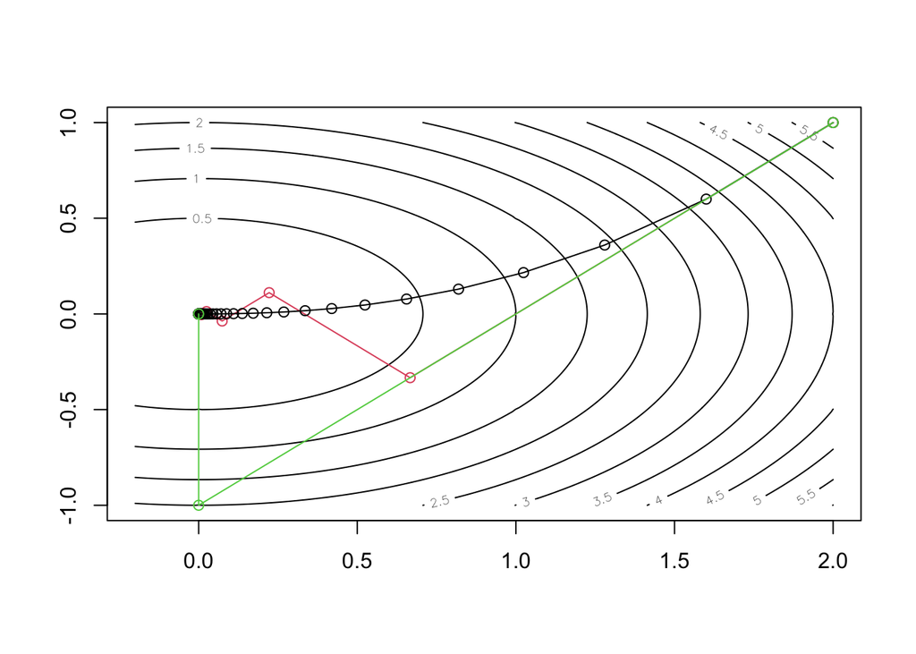

```r
plt<-outer(seq(-0.2,2,0.01), seq(-1,1,0.01), FUN=function(x,y){x^2+2*y^2})
contour(seq(-0.2,2,0.01), seq(-1,1,0.01), plt)


points(out_exact$trajectory[,1], out_exact$trajectory[,2], col=2)
lines(out_exact$trajectory[,1], out_exact$trajectory[,2], col=2)

points(out_const$trajectory[,1], out_const$trajectory[,2])
lines(out_const$trajectory[,1], out_const$trajectory[,2])

points(out_back$trajectory[,1], out_back$trajectory[,2], col=3)
lines(out_back$trajectory[,1], out_back$trajectory[,2], col=3)
```

We know from the theory in notes that
$$f\in C_{||2\mathbf{A}||_2}^{1,1}$$
, i.e., $\nabla f$ is Lipschitz continuous with constant $||2\mathbf{A}||=4$ (the largest eigenvalue). So by the theory in the notes, we have that gradient descent with constant step size should converge whenever $t\in (0, 2/4)$.

```r
out_const <- graddesc_const_step(f,g,x0=c(2,1), tbar=0.4999, epsilon=10^{-5}, Print=FALSE, maxiter=10^6)
```

```
## [1] 4 4
```

The theorem doesn’t say it will diverge when $t>0.5$ but that is usually the case in this problem.

We can also do scaled-gradient descent with a diagonal scaling matrix.

```r
print(scaled_graddesc_const_step)
```

```
## function (f, g, D, x0, tbar, epsilon, Print = TRUE, maxiter = 10^6)
## {
##     print("SCALED GRADIENT DESCENT - CONSTANT STEPSIZE")
##     x = x0
##     iter = 1
##     trajectory <- matrix(0, nr = maxiter, nc = length(x0))
##     trajectory[iter, ] <- x0
##     while (sum(g(x)^2) > epsilon^2 && iter < maxiter) {
##         iter = iter + 1
##         x = x - tbar * D(x) %*% g(x)
##         trajectory[iter, ] <- x
##         if (Print) {
##             print(paste("-------------- Iteration ", iter, " -------------"))
##             print(paste("f(x) = ", signif(f(x), 3), " norm_grad = ",
##                 signif(sqrt(sum(g(x)^2)), 3)))
##         }
##     }
##     return(list(x.opt = x, trajectory = trajectory[1:iter, ],
##         iter = iter - 1))
## }
```

If we use the scaled diagonal matrix given in the notes

$$\begin{align*}
\left(\mathbf{D}^{k}\right)_{i i}=\left(\frac{\partial^{2}
f\left(\mathbf{x}^{k}\right)}{\partial x_{i}^{2}}\right)^{-1}
\end{align*}$$

then we find very fast convergence. For $t=1$ we converge in a single step, for $t=0.5$ it takes a little longer, but still much faster than with the unscaled method.

```r
D<- function(x){
  diag(c(1/2, 1/4))
}

scaled_graddesc_const_step(f,g,D,x0=c(1,1), tbar=1, epsilon=10^{-5})
```

```
## [1] "SCALED GRADIENT DESCENT - CONSTANT STEPSIZE"
## [1] "-------------- Iteration  2  -------------"
## [1] "f(x) =  0  norm_grad =  0"
```

```
## $x.opt
##      [,1]
## [1,]    0
## [2,]    0
##
## $trajectory
##      [,1] [,2]
## [1,]    1    1
## [2,]    0    0
##
## $iter
## [1] 1
```

```r
#scaled_graddesc_const_step(f,g,D,x0=c(1,1), tbar=0.5, epsilon=10^{-5})
```

```r
print(scaled_graddesc_backtracking)
```

```
## function (f, g, D, x0, s, alpha, beta, epsilon, Print = FALSE,
##     maxiter = 10^6)
## {
##     print("SCALED GRADIENT DESCENT - backtracking")
##     x = x0
##     iter = 1
##     trajectory <- matrix(0, nr = maxiter, nc = length(x0))
##     trajectory[iter, ] <- x0
##     while (sum(g(x)^2) > epsilon^2 && iter < maxiter) {
##         iter = iter + 1
##         tbar = s
##         while (f(x) - f(x - tbar * D(x) %*% g(x)) < alpha * tbar *
##             t(g(x)) %*% D(x) %*% g(x)) {
##             tbar = beta * tbar
##         }
##         x = x - tbar * D(x) %*% g(x)
##         trajectory = rbind(trajectory, c(x))
##         if (Print) {
##             print(paste("-------------- Iteration ", iter, " -------------"))
##             print(paste("f(x) = ", signif(f(x), 3), " norm_grad = ",
##                 signif(sqrt(sum(g(x)^2)), 3)))
##         }
##     }
##     return(list(x.opt = x, trajectory = trajectory[1:iter, ],
##         iter = iter - 1))
## }
```

```r
scaled_graddesc_backtracking(f,g,D,x0=c(1,1), s=10, alpha=0.25, beta=0.5, epsilon=10^{-5})
```

```
## [1] "SCALED GRADIENT DESCENT - backtracking"
```

```
## $x.opt
##              [,1]
## [1,] 9.536743e-07
## [2,] 9.536743e-07
##
## $trajectory
##       [,1] [,2]
##  [1,]    1    1
##  [2,]    0    0
##  [3,]    0    0
##  [4,]    0    0
##  [5,]    0    0
##  [6,]    0    0
##  [7,]    0    0
##  [8,]    0    0
##  [9,]    0    0
## [10,]    0    0
## [11,]    0    0
##
## $iter
## [1] 10
```

### Rosenbrock function

This is a classic example of a ill-condition problem:

$$\begin{align*}
\min \left\{f\left(x_{1},
x_{2}\right)=100\left(x_{2}-x_{1}^{2}\right)^{2}+\left(1-x_{1}\right)^{2}\right\}
\end{align*}$$

Let’s code the function, its gradient, and check our calculation numerically.

```r
f<- function(x){
  100*(x[2]-x[1]^2)^2+(1-x[1])^{2}
}

g<-function(x){
  dx1 <- -400*x[1]*(x[2]-x[1]^2)- 2*(1-x[1])
  dx2 <- 200*(x[2]-x[1]^2)
  return(c(dx1,dx2))
}

library(numDeriv)
x=c(2.23, 1.24)
grad(f,x)
```

```
## [1] 3332.207 -746.580
```

```r
g(x)
```

```
## [1] 3332.207 -746.580
```

```r
kappa(numDeriv::hessian(f, x), exact=TRUE)
```

```
## [1] 105.6324
```

If we then do gradient descent with backtracking we find we need a lot of iterations to converge:

```r
out_back <- graddesc_backtracking(f,g,x0=c(2,5), s=2,alpha=0.25,
                                  beta=0.5, epsilon=10^{-5}, Print=FALSE)
print(paste("-----", out_back$iter, "Iterations required -----"))
```

```
## [1] "----- 6890 Iterations required -----"
```

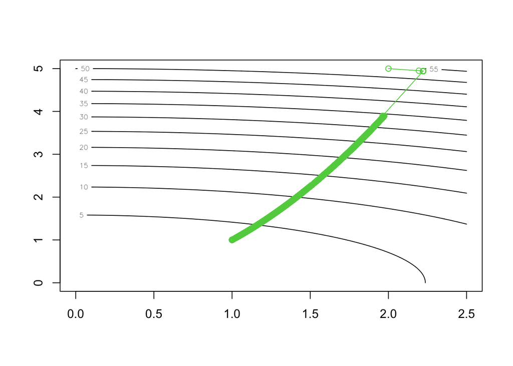

```r
plt<-outer(seq(0,2.5,0.01), seq(0,5,0.01), FUN=function(x,y){x^2+2*y^2})
contour(seq(0,2.5,0.01), seq(0,5,0.01), plt)

points(out_back$trajectory[,1], out_back$trajectory[,2], col=3)
lines(out_back$trajectory[,1], out_back$trajectory[,2], col=3)
```

In this case, using a diagonal scaling matrix for the gradients doesn’t work particularly well either. We will see an approach that works well for this problem next week.

### Sensitive linear system

Let
$$\mathbf{A}=\begin{pmatrix} 1+10^{-5}
& 1\\ 1& 1+10^{-5}\end{pmatrix}.$$
Compute the condition number of $\mathbf{A}$. Solve the linear systems
$$\mathbf{A}\mathbf{x}=\begin{pmatrix}1\\1\end{pmatrix}\quad
\mbox{ and }
\quad\mathbf{A}\mathbf{x}=\begin{pmatrix}1.1\\1\end{pmatrix}$$
and validate the inequality

$$\frac{||\delta
\mathbf{x}||}{||\mathbf{x}||} \leq \kappa(\mathbf{A}) \frac{||\delta
\mathbf{b}||}{||\mathbf{b}||}.$$

```r
A <- matrix(c(1+10^{-5}, 1, 1, 1+10^{-5}), nr=2, byrow=T)
kappa(A)
```

```
## [1] 200002
```

```r
x<-solve(A, c(1,1))
dx = solve(A, c(1.1,1))-x
ndb=0.1 ##|| delta b||
nb= sqrt(2) ## ||b||
sqrt(sum(dx^2)) /sqrt(sum(x^2))<= kappa(A)*ndb/nb
```

```
## [1] TRUE
```

## Quadratic Optimization Benchmark

Consider the quadratic minimization problem
$$\begin{align*}
\min_{\mathbf{x}} \left\{\mathbf{x}^{\top} \mathbf{A}\mathbf{x}:
\mathbf{x}\in \mathbb{R}^{5}\right\}
\end{align*}$$
where $\mathbf{A}$ is the $5 \times 5$ Hilbert matrix defined by
$$\begin{align*}
\mathbf{A}_{i, j}=\frac{1}{i+j-1}, \quad i, j=1,2,3,4,5
\end{align*}$$
Write an R function to create the Hilbert matrix of a given size.

This is easy to do as a loop, but here is a particularly efficient way of doing it:

```r
hilbert <- function(n){
  tmp<-outer(1:n, 1:n, FUN="+")
  1/(tmp-1)
}

(A=hilbert(5))
```

```
##           [,1]      [,2]      [,3]      [,4]      [,5]
## [1,] 1.0000000 0.5000000 0.3333333 0.2500000 0.2000000
## [2,] 0.5000000 0.3333333 0.2500000 0.2000000 0.1666667
## [3,] 0.3333333 0.2500000 0.2000000 0.1666667 0.1428571
## [4,] 0.2500000 0.2000000 0.1666667 0.1428571 0.1250000
## [5,] 0.2000000 0.1666667 0.1428571 0.1250000 0.1111111
```

We first note that this matrix is symmetric ($\mathbf{A}=\mathbf{A}^{\top}$) and positive semi-definite:

```r
max(abs(A-t(A)))  # should be close to zero
```

```
## [1] 0
```

```r
eigen(A)$values # list eigenvalues
```

```
## [1] 1.567051e+00 2.085342e-01 1.140749e-02 3.058980e-04 3.287929e-06
```

Second, we compute
$$\nabla f(\mathbf{x})=2\mathbf{A}\mathbf{x}\,,\quad\text{ and }\quad
\nabla^2 f(\mathbf{x})=2\mathbf{A}\,.$$

We already know there’s a global minimum at $\mathbf{x}=0$ (global optimality conditions for quadratic functions).

Run the following methods and compare the number of iterations required by each of the methods when the initial vector is $\mathbf{x}^{0}=(1,2,3,4,5)^{\top}$ to obtain a solution $\mathbf{x}^*$ with $\|\nabla f(\mathbf{x})\| \leq 10^{-4}:$

- Gradient method with backtracking stepsize rule and parameters $\alpha=0.5, \beta=$ $0.5, s=1$

```r
f <- function(x){
  t(x)%*%A%*%x
}
g <- function(x){
  2*A%*%x
}

out<-graddesc_backtracking(f,g,x0=1:5, s=1, alpha=0.5, beta=0.5, epsilon=10^{-4}, Print=FALSE)
print("Estimated Minima:")
```

```
## [1] "Estimated Minima:"
```

```r
print(out$x.opt)
```

```
##             [,1]
## [1,] -0.00672795
## [2,]  0.05565571
## [3,] -0.05252335
## [4,] -0.11474086
## [5,]  0.12550715
```

```r
print(paste("-----", out$iter, "Iterations required -----"))
```

```
## [1] "----- 3301 Iterations required -----"
```

- Gradient method with backtracking stepsize rule and parameters $\alpha=0.1, \beta=$ $0.5, s=1$

```r
out<-graddesc_backtracking(f,g,x0=1:5, s=1, alpha=0.1, beta=0.5, epsilon=10^{-4}, Print=FALSE)
print("Estimated Minima:")
```

```
## [1] "Estimated Minima:"
```

```r
print(out$x.opt)
```

```
##              [,1]
## [1,] -0.005581173
## [2,]  0.045207362
## [3,] -0.036459701
## [4,] -0.108956299
## [5,]  0.111941598
```

```r
print(paste("-----", out$iter, "Iterations required -----"))
```

```
## [1] "----- 3732 Iterations required -----"
```

- Diagonally scaled gradient method with diagonal elements $\mathbf{D}_{i,i}=\frac{1}{\mathbf{A}_{i,i}}, i=$ 1,2,3,4,5 and exact line search;

Following the calculations from the exercises in the notes, we know that the exact line search for this problem is given by
$$t^k=\frac{\mathbf{d}^{\top}\nabla
f(\mathbf{x})}{2\mathbf{d}^{\top}\mathbf{A}\mathbf{d}}\,,$$
where $\mathbf{d}^k$ is the direction taken at the $k-$th iteration which is $\mathbf{d}^k=-\nabla f(\mathbf{x}^k)$ in the usual gradient method, and $\mathbf{d}^k=-\mathbf{D}^k\nabla f(\mathbf{x}^k)$ in the scaled gradient method. This leads to the code below:

```r
D <- function(x){
  diag(1/diag(A))
}


scaled_graddesc_exact <- function(f,g,D, x0, epsilon, Print=TRUE){
  # Gradient method with constant stepsize. The method
  # terminates when ||g(x)|| <epsilon
  # INPUT
  # f - the objective function
  # g - gradient of the objective function
  # x0 - initial point
  # t  -  constant stepsize
  # epsilon ... tolerance parameter
  ####
  # OUTPUT
  # x.opt = optimal solution (up to a tolerance) of min f(x)
  # f.opt = optimal function value
  print("SCALED GRADIENT DESCENT - CONSTANT STEPSIZE")
  x=x0
  iter=0
  trajectory <- x0
  while (sum(g(x)^2)>epsilon^2){
    iter=iter+1
    d =D(x)%*%g(x)
    tbar = c(t(d)%*%g(x)/(2*t(d)%*%A%*%d))
    x=x - tbar*d
    trajectory=rbind(trajectory, c(x));
    if(Print){
      print(paste('-------------- Iteration ', iter, ' -------------'))
      print(paste("f(x) = ", signif(f(x),3), " norm_grad = ", signif(sqrt(sum(g(x)^2)),3)))
    }
  }
  return(list(x.opt=x, trajectory=trajectory, iter=iter))
}






out <-scaled_graddesc_exact(f,g,D, x0=1:5, epsilon=10^{-4}, Print=FALSE)
```

```
## [1] "SCALED GRADIENT DESCENT - CONSTANT STEPSIZE"
```

```r
print("Estimated Minima:")
```

```
## [1] "Estimated Minima:"
```

```r
print(out$x.opt)
```

```
##              [,1]
## [1,] -0.002750848
## [2,]  0.026359288
## [3,] -0.032294140
## [4,] -0.042836367
## [5,]  0.055220288
```

```r
print(paste(out$iter, " Iterations required"))
```

```
## [1] "235  Iterations required"
```

- Diagonally scaled gradient method with diagonal elements $\mathbf{D}_{i,i}=\frac{1}{\mathbf{A}_{i,i}}, i=$ 1,2,3,4,5 and backtracking line search with parameters $\alpha=0.1, \beta=0.5$ $s=1$.

```r
out <-scaled_graddesc_backtracking(f,g,D, x0=1:5, s=1, alpha=0.1, beta=0.5, epsilon=10^{-4}, Print=FALSE)
```

```
## [1] "SCALED GRADIENT DESCENT - backtracking"
```

```r
print("Estimated Minima:")
```

```
## [1] "Estimated Minima:"
```

```r
print(out$x.opt)
```

```
##              [,1]
## [1,] -0.002700213
## [2,]  0.026450663
## [3,] -0.032753489
## [4,] -0.043026440
## [5,]  0.055926606
```

```r
print(paste(out$iter, " Iterations required"))
```

```
## [1] "104  Iterations required"
```